# Shopping Dataset for Marketing Purposes

Shopping Dataset for Marketing  
Data Science 1 with R (STAT 301-1)

Author

Sophie Langaigne

Published

December 10, 2025

**Github Repo Link**

[Final Project Link](https://github.com/stat301-1-2025-fall/final-project-1-sophielangaigne2027-hash.git)

# Introduction

#### Purpose

I have chosen the Shopping Behavior Dataset from Kaggle because it offers a multifaceted view of individual consumer transactions, demographics, product details, frequency and promos. This dataset is perfect for marketing analytics which is something I’m very passionate about exploring. Understanding how certain factors can affect consumer behaviour. In addition, I’m currently working on a different dataset for my marketing classes and I wanted to combine my interests.

#### Rationale for Dataset Selection

I have chosen the Shopping Behavior Dataset from Kaggle because it offers a multifaceted view of individual consumer transactions, demographics, product details, frequency, and promotions. This dataset is ideal for marketing analytics, which is an area I am passionate about exploring since I am also in the Integrated Marketing Certificate Program. Understanding how certain factors affect consumer behavior is valuable for both academic and practical applications. Additionally, I am currently working on a different dataset for my marketing classes, and I wanted to integrate my interests across both projects.

#### Data Quality and Complexity Assessment

Dataset Dimensions: 3,900 observations and 18 variables

Categorical Variables (11): Customer ID, Payment Method, Promo Code Used, Discount Applied, Shipping Type, Subscription Status, Season, Color, Size, Location, and Category

Numeric Variables (4): Age, Previous Purchases, Purchase Amount (USD), and Review Rating

#### Data Completeness Chart

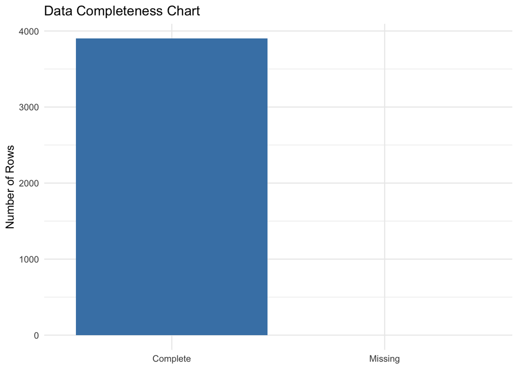

Figure 1

#### Potential Missingness

Some categorical nulls like Promo Code Used and Discount Applied may represent implicit “No”/“NA” values rather than true missing data. However based on my missingness test, this dataset does not require a lot of tidying because there is no missingness. In addition, high dollar amounts could not register in the dataset since there might be data entry limits with the website, there could be skewness in the data but within my EDA I will explore this further. Upon further research in Figure 1, this graph shows that this dataset is considered complete with no missing values.

#### Data Quality Notes

This dataset is considered substantially complete despite the presence of “No” values in the promo code variable. These missing values can be appropriately handled through standard data cleaning techniques. The variables demonstrate sufficient complexity and diversity for robust data analysis. The dataset contains numerous unique values across categorical variables, and some variables may require string manipulation or reference during analysis. Overall, the dataset is well-suited for exploring relationships between consumer demographics, purchasing behavior, and product preferences, making it an excellent choice for applied marketing analytics.

# EDA

### Univariate Analysis on Purchase Amount

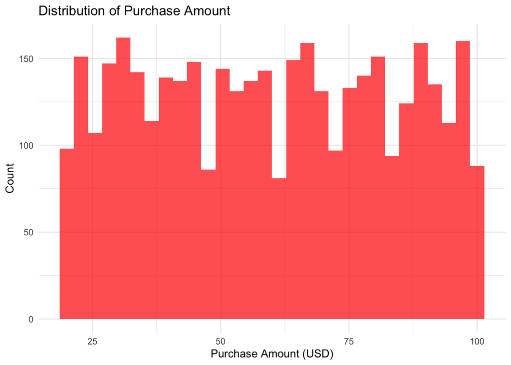

Figure 2

#### Insights on the Distribution by Purchases

Figure 2 displays the distribution of purchase amounts is fairly uniform, with customers making purchases across the full price range rather than clustering around specific dollar amounts. This suggests the store sells a balanced mix of products at different price points, with no strong tendency toward either low-cost or high-cost purchases that may skew data.

### BoxPlot of Purchase Amount

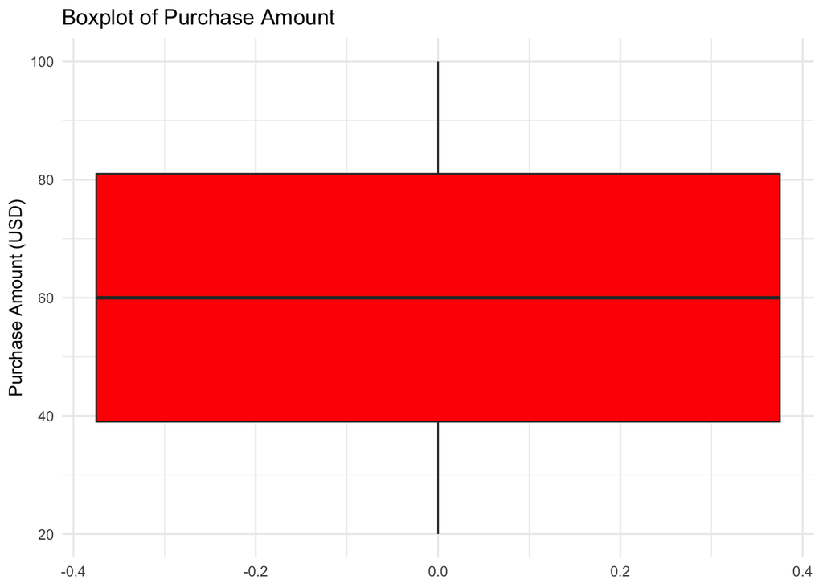

Figure 3

### Univariate Variate Analysis on Frequency of Items Bought

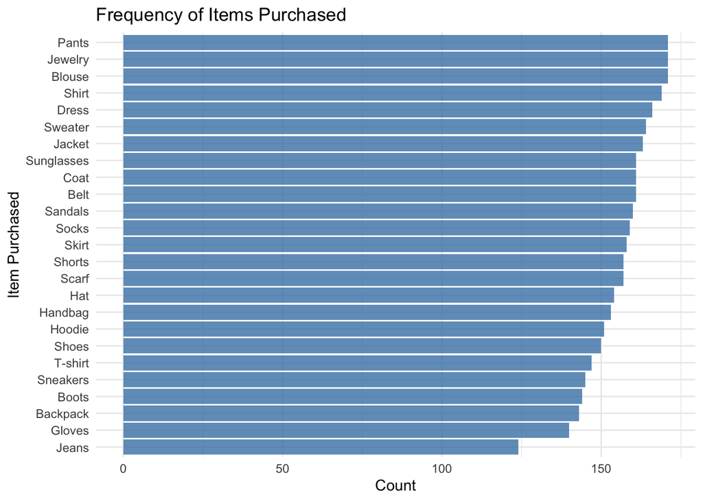

Figure 4

### Age Univariate Analysis on the Distribution of Customer Age

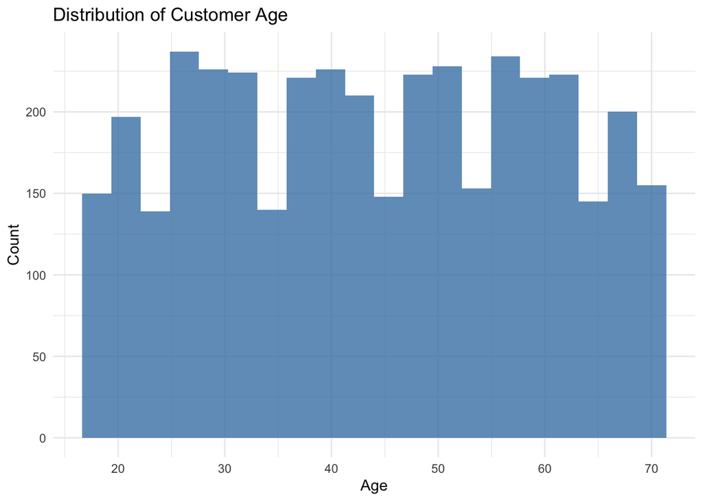

Figure 5